## The Model

### Model Overview

This model has the same compartments as the *Characteristics of ID* model:

- **S** - uninfected and susceptible individuals
- **P** - individuals who are infected and do not yet show symptoms. Those individuals can potentially be infectious
- **A** - individuals who are infected and do not show symptoms. Those individuals can potentially be infectious
- **I** - individuals who are infected and show symptoms. Those individuals are likely infectious, but the model allows to adjust this, including no infectiousness.
- **R** - recovered/removed individuals. Those individuals have recovered and are immune. They can loose their immunity in this model.
- **D** - individuals who have died due to the disease.

We include the following processes in this model:

- Susceptible individuals (S) can become infected by pre-symptomatic (P), asymptomatic (A) or symptomatic (I) hosts. The rates at which infections from the different types of infected individuals (P, A and I) occur are governed by 3 parameters, *b<sub>P</sub>*, *b<sub>A</sub>*, and *b<sub>I</sub>*.
- All infected individuals first enter the presymptomatic stage. They remain there for some time (determined by rate *g<sub>P</sub>*, the inverse of which is the average time spent in the presymptomatic stage). A fraction *f* of presymptomatic hosts move into the asymptomatic category, and the rest become symptomatic infected hosts.
- Asymptomatic infected hosts recover after some time (specified by the rate *g<sub>A</sub>*). Similarly, the rate *g<sub>I</sub>* determines the duration the symptomatic hosts stay in the symptomatic state. For symptomatic hosts, two outcomes are possible. Either recovery or death. The parameter *d* determines the fraction of hosts that die.
- Recovered individuals are initially immune to reinfection. They can loose their immunity at rate *w* and return to the susceptible compartment.
- New susceptibles enter the system/model at a fixed rate *m*. From each compartment (apart from the dead compartment), hosts “leave” after some time (i.e. they die) at rate *n*. The inverse of this rate is the average lifespan of a host.
- The rates of transmission, *b<sub>P</sub>*, *b<sub>A</sub>* and *b<sub>I</sub>* can vary seasonally/annually, modeled as a sinusoidal function. The strength of this seasonal variation is controlled by the parameter *s*.

Note that we only track people that die due to the disease in our $D$ compartment. All hosts dying due to other causes just “exit the system” and we don’t further keep track of them (though we could add another compartment to “collect” and track all individuals who died from non-disease-related causes.)

### Model Implementation

The flow diagram and equations describe the model implemented in this app:

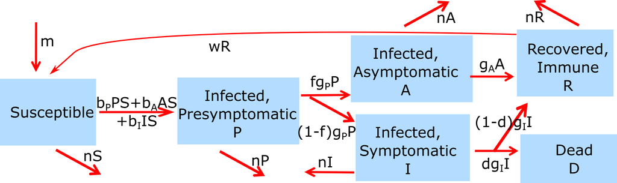

Flow diagram for this model.

$$b_P^s = b_P(1+s \sin(2\pi t / T))$$
$$b_A^s = b_A(1+s \sin(2\pi t /T))$$
$$b_I^s = b_I(1+s \sin(2\pi t /T))$$
$$\dot S = m - S (b_P^s P + b_A^s A + b_I^s I) + wR - n S$$
$$\dot P = S (b_P^s P + b_A^s A + b_I^s I) - g_P P - n P$$
$$\dot A = f g_P P - g_A A - n A$$
$$\dot I = (1-f) g_P P - g_I I - n I$$
$$\dot R = g_A A + (1-d) g_I I - wR - n R$$
$$\dot D = d g_I I$$

Since we do not track people dying due to non-disease causes, all the “n - arrows” are not pointing to another compartment, instead of those individuals just “leave the system”. Similarly new susceptibles enter the system (are born) from “outside the system”.

Also note that the transmission rates, *b<sub>I</sub>*, can be time varying as described above. The parameter *T* is set depending on the time units chosen for the model. For example if you want to run the model in units of days, the underlying simulation code will set *T=365*, similarly, for weeks it will be *T=52*. This ensures that the seasonal variation always has a period of a year.